# Project 2: Thursday Data

## Introduction:

In this project I will be using the `OnlineNewsPopularity.csv` data, which is a data set about various articles that are published along with various article and publishing attributes. The goal of this project is to accurately predict the number of times that a particular article will be "shared" on social media given its attributes.

## Data Summary

Overall, the Online News Popularity data has *39644* observations and *62* variables. There are a total of *7267* observations for articles that were published on a Thursday, and that is the subset of observations that I will be using for this report. From the initial variables, I will be considering *46* of them as potentially having an effect on number of shares.

There are 5 groups of variables that have similar themes in this data set. The variables within each group likely have high correlations with each other. The variable groups are about:

1. Number of words/keywords/media
2. Digital channel type
3. Shares by keyword
4. Typical shares of articles in Mashable
5. Sentiment and Polarity

**Correlation Plots for Number of Word Variables:**

As seen below, many of the variables are highly correlated and might need to be removed.

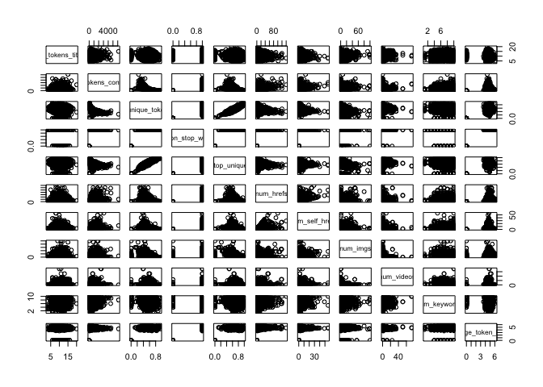

**Shares by Keyword Variables:**

As seen below, many of the variables seem correlated and might need to be removed.

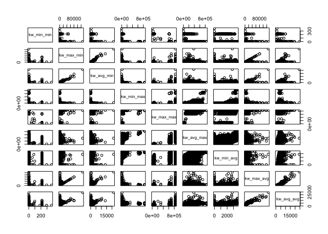

**Mashable Shares Variables:**

These variables seem to have very similar distributions. It is not clear whether there will be any relationship with overall shares.

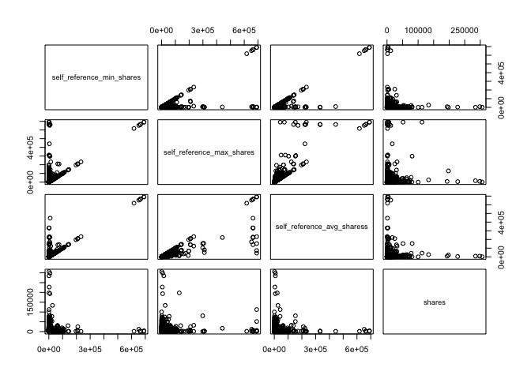

**Sentiment/Polarity Variables:**

When comparing variables measuring positive and negative polarities, there seems to be moderate to strong correlations.

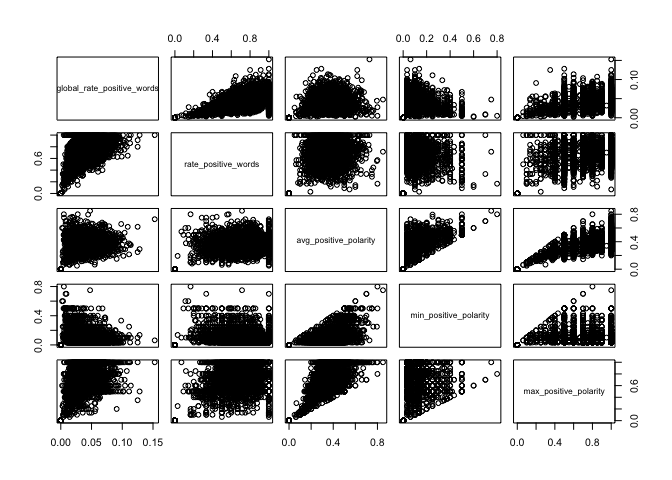

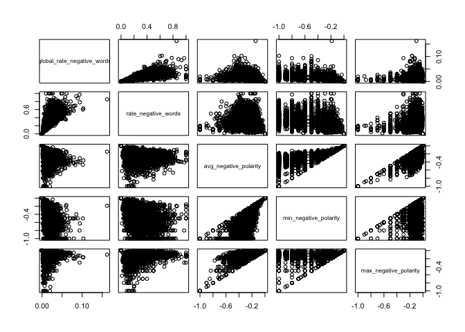

## Modeling

First, I will split the data into training and test sets. The training data set will contain 70% of the data observations, and the test set will contain the remaining 30%.

Dimensions of the train and test sets:

```
## [1] 5086   46

## [1] 2181   46
```

### Linear Model

I will first begin by fitting a linear regression model with ALL of the variables.

```
##
## Call:
## lm(formula = shares ~ ., data = dTrain)
##
## Residuals:
##    Min     1Q Median     3Q    Max
## -36000  -2344   -980    426 301709
##
## Coefficients: (1 not defined because of singularities)
##                                 Estimate Std. Error t value Pr(>|t|)
## (Intercept)                   -4.777e+03  2.061e+03  -2.318  0.02051 *
## n_tokens_title                 1.764e+02  7.163e+01   2.462  0.01383 *
## n_tokens_content              -1.721e-01  6.252e-01  -0.275  0.78311
## n_unique_tokens                9.282e+03  4.932e+03   1.882  0.05989 .
## n_non_stop_words              -1.362e+03  4.196e+03  -0.324  0.74557
## n_non_stop_unique_tokens      -6.401e+03  4.150e+03  -1.542  0.12303
## num_hrefs                      1.309e+01  1.822e+01   0.719  0.47239
## num_self_hrefs                 1.907e+01  5.094e+01   0.374  0.70818
## num_imgs                       2.157e+01  2.253e+01   0.958  0.33833
## num_videos                     1.465e+01  4.142e+01   0.354  0.72356
## average_token_length          -5.570e+01  6.219e+02  -0.090  0.92864
## num_keywords                  -2.019e+02  9.210e+01  -2.192  0.02841 *
## data_channel_is_lifestyle     -5.248e+02  8.345e+02  -0.629  0.52941
## data_channel_is_entertainment -5.051e+02  6.226e+02  -0.811  0.41720
## data_channel_is_bus            4.051e+02  6.624e+02   0.612  0.54083
## data_channel_is_socmed        -8.246e+02  8.045e+02  -1.025  0.30538
## data_channel_is_tech           2.309e+02  6.714e+02   0.344  0.73089
## data_channel_is_world          3.623e+02  7.137e+02   0.508  0.61169
## kw_min_min                     1.058e+01  4.374e+00   2.418  0.01562 *
## kw_max_min                    -3.993e-01  1.777e-01  -2.248  0.02463 *
## kw_avg_min                     4.605e+00  1.148e+00   4.012 6.10e-05 ***
## kw_min_max                    -1.273e-03  2.664e-03  -0.478  0.63270
## kw_max_max                     2.243e-03  1.530e-03   1.466  0.14268
## kw_avg_max                    -1.669e-04  2.104e-03  -0.079  0.93677
## kw_min_avg                    -9.637e-01  1.937e-01  -4.976 6.71e-07 ***
## kw_max_avg                    -2.392e-01  7.332e-02  -3.263  0.00111 **
## kw_avg_avg                     2.334e+00  3.799e-01   6.144 8.69e-10 ***
## self_reference_min_shares      5.047e-02  1.805e-02   2.796  0.00520 **
## self_reference_max_shares      5.632e-02  9.705e-03   5.804 6.88e-09 ***
## self_reference_avg_sharess    -1.018e-01  2.516e-02  -4.047 5.27e-05 ***
## global_subjectivity            5.906e+03  2.194e+03   2.692  0.00712 **
## global_sentiment_polarity     -2.863e+03  4.320e+03  -0.663  0.50747
## global_rate_positive_words    -1.850e+03  1.830e+04  -0.101  0.91951
## global_rate_negative_words    -3.840e+04  3.576e+04  -1.074  0.28293
## rate_positive_words           -1.027e+03  2.873e+03  -0.358  0.72061
## rate_negative_words                   NA         NA      NA       NA
## avg_positive_polarity         -2.330e+03  3.509e+03  -0.664  0.50678
## min_positive_polarity         -2.914e+03  2.911e+03  -1.001  0.31696
## max_positive_polarity          9.105e+02  1.087e+03   0.838  0.40223
## avg_negative_polarity          5.565e+03  3.254e+03   1.710  0.08733 .
## min_negative_polarity         -2.288e+03  1.177e+03  -1.945  0.05183 .
## max_negative_polarity         -4.778e+03  2.680e+03  -1.783  0.07462 .
## title_subjectivity            -7.179e+02  6.776e+02  -1.059  0.28946
## title_sentiment_polarity      -1.381e+03  6.409e+02  -2.155  0.03125 *
## abs_title_subjectivity        -7.987e+02  9.190e+02  -0.869  0.38479
## abs_title_sentiment_polarity   2.067e+03  1.015e+03   2.035  0.04185 *
## ---
## Signif. codes:  0 '***' 0.001 '**' 0.01 '*' 0.05 '.' 0.1 ' ' 1
##
## Residual standard error: 10360 on 5041 degrees of freedom
## Multiple R-squared:  0.06327,    Adjusted R-squared:  0.05509
## F-statistic: 7.738 on 44 and 5041 DF,  p-value: < 2.2e-16
```

```
##
## Call:
## lm(formula = shares ~ data_channel_is_entertainment + kw_min_min +
##     kw_max_max + kw_avg_max + kw_max_avg + kw_avg_avg + min_positive_polarity,
##     data = dTrain)
##
## Residuals:
##    Min     1Q Median     3Q    Max
## -27466  -2101  -1162   -219 301691
##
## Coefficients:
##                                 Estimate Std. Error t value Pr(>|t|)
## (Intercept)                   -2.626e+03  1.250e+03  -2.100  0.03573 *
## data_channel_is_entertainment -3.720e+02  3.912e+02  -0.951  0.34176
## kw_min_min                     1.215e+01  4.396e+00   2.765  0.00572 **
## kw_max_max                     1.699e-03  1.473e-03   1.153  0.24898
## kw_avg_max                    -7.620e-04  1.532e-03  -0.497  0.61891
## kw_max_avg                     3.803e-02  5.112e-02   0.744  0.45688
## kw_avg_avg                     1.423e+00  2.443e-01   5.825 6.08e-09 ***
## min_positive_polarity         -1.239e+03  2.100e+03  -0.590  0.55505
## ---
## Signif. codes:  0 '***' 0.001 '**' 0.01 '*' 0.05 '.' 0.1 ' ' 1
##
## Residual standard error: 10490 on 5078 degrees of freedom
## Multiple R-squared:  0.03202,    Adjusted R-squared:  0.03069
## F-statistic:    24 on 7 and 5078 DF,  p-value: < 2.2e-16
```

Looking at the plots for the model, it seems that there are leverage points affecting the predictions.

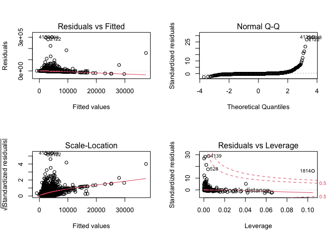

```
##
## Call:
## lm(formula = shares ~ data_channel_is_entertainment + kw_min_min +
##     kw_max_max + kw_avg_max + kw_max_avg + kw_avg_avg + min_positive_polarity,
##     data = dTrain, weights = as.numeric(w))
##
## Weighted Residuals:
##     Min      1Q  Median      3Q     Max
## -5300.6 -1379.2  -765.1    74.1 31316.2
##
## Coefficients:
##                                 Estimate Std. Error t value Pr(>|t|)
## (Intercept)                   -1.378e+02  3.817e+02  -0.361  0.71816
## data_channel_is_entertainment -5.697e+02  1.183e+02  -4.815 1.52e-06 ***
## kw_min_min                     2.360e+00  1.343e+00   1.757  0.07890 .
## kw_max_max                     4.596e-04  4.492e-04   1.023  0.30635
## kw_avg_max                    -2.225e-03  4.693e-04  -4.741 2.19e-06 ***
## kw_max_avg                    -6.966e-02  2.286e-02  -3.047  0.00233 **
## kw_avg_avg                     1.085e+00  8.102e-02  13.393  < 2e-16 ***
## min_positive_polarity         -9.999e+02  6.375e+02  -1.568  0.11685
## ---
## Signif. codes:  0 '***' 0.001 '**' 0.01 '*' 0.05 '.' 0.1 ' ' 1
##
## Residual standard error: 3147 on 4995 degrees of freedom
## Multiple R-squared:  0.07093,    Adjusted R-squared:  0.06963
## F-statistic: 54.48 on 7 and 4995 DF,  p-value: < 2.2e-16
```

### Non-Linear Models

First, I will fit a simple Regression Tree in order to predict shares. Here is the code below:

```r
set.seed(100)
trctrl <- trainControl(method="repeatedcv", number=10, repeats = 3)
metric = 'RMSE'
tree_fit <- train(shares ~., data = dTrain, method = "rpart", metric = metric, trControl = trctrl,
                 preProcess = c("center", "scale") )
```

I will also fit a bagged tree to predict shares. Here is the code for that:

```r
bag_fit <- train(shares ~., data = dTrain, method = "treebag", metric = metric, trControl = trctrl,
                 preProcess = c("center", "scale") )
```

## Test Set Prediction

I will fit each of the 3 models (Linear Regression, Regression Tree, Bagged Tree) on the test data set.

Here are the corresponding RMSE values:

- The RMSE for the Linear Regression model on the test set is 5557.8891323.
- The RMSE for the Regression Tree model on the test set is 5638.5807407.
- The RMSE for the Bagged Tree model on the test set is 5811.8151995.

## Conclusion

Comparing the linear and non-linear methods based on test MSE, the Linear Regression model performed the best in predicting number of shares, despite having a high MSE and low adjusted R<sup>2</sup> on its own.